# Introduction to R

NAFC | Fisheries and Oceans Canada | 2019-01-16

## What we hope you'll be able to do by the end of this presentation:

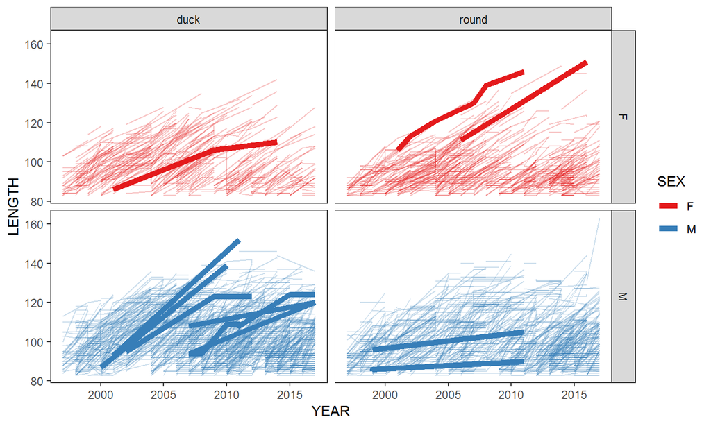

## What we hope you'll be able to do by the end of this presentation:

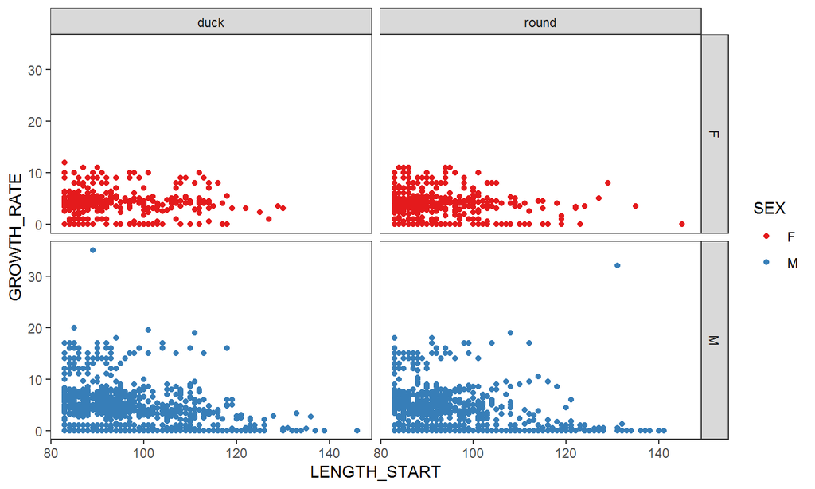

## dplyr is:

- A tool for working with tidy data
- Works by using simple verbs, that each do one thing well:
  - `mutate(data, <other arguments>)`
  - `arrange(data, <other arguments>)`
  - `group_by(data, <other arguments>)`
  - `summarize(data, <other arguments>)`
  - …
- Lets you apply these verbs in order to create new tidy dataframes:
- `new_data <- old_data %>% select(<something>)%>% mutate(<something else>)%>% ...`

## First make sure we're on the same page:

```r
library(readxl)
library(tidyr)
library(dplyr)
library(ggplot2)


duck <- read_excel("data/Duck Islands Movement.xlsx")
round <- read_excel("data/Round Island Movement.xlsx")

tags <- bind_rows(duck, round)
tags

tidy_tags <- select(tags, SIDE:NOTCH) %>%
    drop_na(SIDE, ISLAND, YEAR, TAG)%>%
    filter(SIDE!="s")
```

## `mutate()`: Creating and altering exisiting variables

- `mutate()` lets you change columns, or create new columns
- You can add as many columns as you want in one `mutate` statement
- it does not add or remove rows, change the order of the data, or not remove columns

## `mutate()`: Creating and altering exisiting variables

```r
#Let's say we want to see how catches of legal (82.5 mm+) and non-legal size
#have changed over time in the tagging data, compared to the average size of all
#lobsters caught:
tidy_tags <- tidy_tags %>%
    mutate(LEGAL_SIZE = LENGTH > 82.5,
           LENGTH_AVERAGE = mean(LENGTH),
           #We can also change an existing variable:
           SIDE = tolower(SIDE)
           )

tidy_tags
```

## `mutate()`: Creating and altering exisiting variables

```
## # A tibble: 16,179 x 20
##    SIDE  SIDEN AREA2 AREA    LOC ISLAND  YEAR MONTH   DAY SAMPLE   TTY
##    <chr> <dbl> <chr> <chr> <dbl> <chr>  <dbl> <dbl> <dbl>  <dbl> <dbl>
##  1 out       2 10    4       210 duck    2001     9    25      3     1
##  2 out       2 4     4       210 duck    2004     8     7     22     1
##  3 out       2 4     4       210 duck    2004     9    16      7     1
##  4 out       2 10    4       210 duck    2001     9    25      3     1
##  5 out       2 11    4       210 duck    2002    10     3      2     1
##  6 out       2 9     4       210 duck    2001     9    25      3     1
##  7 out       2 11    4       210 duck    2002    10     7      5     1
##  8 out       2 8     4       210 duck    2001     9    25      3     1
##  9 out       2 8     4       210 duck    2001    10     2      9     1
## 10 out       2 7     4       210 duck    2001     9    25      3     1
## # ... with 16,169 more rows, and 9 more variables: TAG <chr>,
## #   LENGTH <dbl>, CAT <dbl>, CLUTCH <dbl>, RECAP <dbl>, SEX <chr>,
## #   NOTCH <dbl>, LEGAL_SIZE <lgl>, LENGTH_AVERAGE <dbl>
```

## `mutate()`: Creating and altering exisiting variables

```r
#Now we can plot this:
legal_size_plot <- ggplot(tidy_tags, aes(x=YEAR, y= LENGTH, color = LEGAL_SIZE))+
    facet_grid(ISLAND~SIDE)+
    geom_point()+
    geom_hline(aes(yintercept = LENGTH_AVERAGE))

print(legal_size_plot)
```

## `mutate()`: Creating and altering exisiting variables

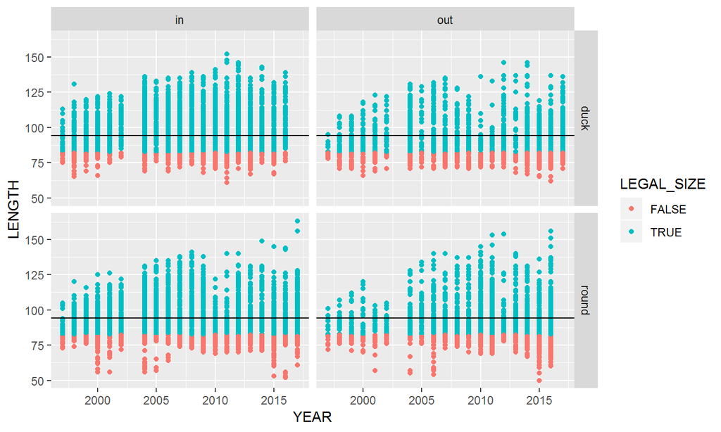

## Exercise: working with `mutate`

Create a new data frame called `legal_size_tags`, that takes the `tidy_tags` data frame, creates the new `LEGAL_SIZE` column, and then use the `filter` command to exclude all of the lobsters than are less than legal size.

## Exercise: working with `mutate`

Create a new data frame called `legal_size_tags`, that takes the `tidy_tags` data frame, creates the new `LEGAL_SIZE` column, and then use the `filter` command to exclude all of the lobsters than are less than legal size.

```r
legal_size_tags <- tidy_tags %>%
    mutate(LEGAL_SIZE = LENGTH > 82.5) %>%
    filter(LEGAL_SIZE == TRUE)

legal_size_tags <- tidy_tags %>%
    mutate(LEGAL_SIZE = LENGTH > 82.5) %>%
    filter(LENGTH > 82.5)

legal_size_tags
```

```
## # A tibble: 12,837 x 20
##    SIDE  SIDEN AREA2 AREA    LOC ISLAND  YEAR MONTH   DAY SAMPLE   TTY
##    <chr> <dbl> <chr> <chr> <dbl> <chr>  <dbl> <dbl> <dbl>  <dbl> <dbl>
##  1 out       2 10    4       210 duck    2001     9    25      3     1
##  2 out       2 4     4       210 duck    2004     8     7     22     1
##  3 out       2 4     4       210 duck    2004     9    16      7     1
##  4 out       2 11    4       210 duck    2002    10     3      2     1
##  5 out       2 9     4       210 duck    2001     9    25      3     1
##  6 out       2 11    4       210 duck    2002    10     7      5     1
##  7 out       2 8     4       210 duck    2001     9    25      3     1
##  8 out       2 8     4       210 duck    2001    10     2      9     1
##  9 out       2 7     4       210 duck    2001     9    25      3     1
## 10 out       2 7     4       210 duck    2001    10     2      9     1
## # ... with 12,827 more rows, and 9 more variables: TAG <chr>,
## #   LENGTH <dbl>, CAT <dbl>, CLUTCH <dbl>, RECAP <dbl>, SEX <chr>,
## #   NOTCH <dbl>, LEGAL_SIZE <lgl>, LENGTH_AVERAGE <dbl>
```

## `group_by()`: breaking data into groups

- `group_by()` is a function for telling `dplyr` that any further analyses should be done *within the selected groups*
- by itself, it does not change how the data look at all, but it affects all the stages after it
- Can group by a *single* variable, or *multiple* variables
- You can stop grouping by using `ungroup()`

## `group_by()`: breaking data into groups

```r
tidy_tags <- tidy_tags %>%
    group_by(SEX)

tidy_tags
```

## `group_by()`: breaking data into groups

```r
#`group_by()`: breaking data into groups ####

tidy_tags <- tidy_tags %>%
    group_by(SEX)

tidy_tags
```

```
## # A tibble: 16,179 x 20
## # Groups:   SEX [2]
##    SIDE  SIDEN AREA2 AREA    LOC ISLAND  YEAR MONTH   DAY SAMPLE   TTY
##    <chr> <dbl> <chr> <chr> <dbl> <chr>  <dbl> <dbl> <dbl>  <dbl> <dbl>
##  1 out       2 10    4       210 duck    2001     9    25      3     1
##  2 out       2 4     4       210 duck    2004     8     7     22     1
##  3 out       2 4     4       210 duck    2004     9    16      7     1
##  4 out       2 10    4       210 duck    2001     9    25      3     1
##  5 out       2 11    4       210 duck    2002    10     3      2     1
##  6 out       2 9     4       210 duck    2001     9    25      3     1
##  7 out       2 11    4       210 duck    2002    10     7      5     1
##  8 out       2 8     4       210 duck    2001     9    25      3     1
##  9 out       2 8     4       210 duck    2001    10     2      9     1
## 10 out       2 7     4       210 duck    2001     9    25      3     1
## # ... with 16,169 more rows, and 9 more variables: TAG <chr>,
## #   LENGTH <dbl>, CAT <dbl>, CLUTCH <dbl>, RECAP <dbl>, SEX <chr>,
## #   NOTCH <dbl>, LEGAL_SIZE <lgl>, LENGTH_AVERAGE <dbl>
```

## `group_by()`: breaking data into groups

```r
#Here's how you group with multiple different variables
tidy_tags <- tidy_tags %>%
    group_by(SIDE, ISLAND)

tidy_tags
```

## `group_by()`: breaking data into groups

```r
#Here's how you group with multiple different variables
tidy_tags <- tidy_tags %>%
    group_by(SIDE, ISLAND)

tidy_tags
```

```
## # A tibble: 16,179 x 20
## # Groups:   SIDE, ISLAND [4]
##    SIDE  SIDEN AREA2 AREA    LOC ISLAND  YEAR MONTH   DAY SAMPLE   TTY
##    <chr> <dbl> <chr> <chr> <dbl> <chr>  <dbl> <dbl> <dbl>  <dbl> <dbl>
##  1 out       2 10    4       210 duck    2001     9    25      3     1
##  2 out       2 4     4       210 duck    2004     8     7     22     1
##  3 out       2 4     4       210 duck    2004     9    16      7     1
##  4 out       2 10    4       210 duck    2001     9    25      3     1
##  5 out       2 11    4       210 duck    2002    10     3      2     1
##  6 out       2 9     4       210 duck    2001     9    25      3     1
##  7 out       2 11    4       210 duck    2002    10     7      5     1
##  8 out       2 8     4       210 duck    2001     9    25      3     1
##  9 out       2 8     4       210 duck    2001    10     2      9     1
## 10 out       2 7     4       210 duck    2001     9    25      3     1
## # ... with 16,169 more rows, and 9 more variables: TAG <chr>,
## #   LENGTH <dbl>, CAT <dbl>, CLUTCH <dbl>, RECAP <dbl>, SEX <chr>,
## #   NOTCH <dbl>, LEGAL_SIZE <lgl>, LENGTH_AVERAGE <dbl>
```

## `group_by()`: breaking data into groups

`group_by() is not that useful alone, but is incredibly powerful when combined with other commands:

```r
tidy_tags <- tidy_tags %>%
    group_by(SIDE, ISLAND, SEX) %>%
    mutate(LENGTH_AVG = mean(LENGTH))%>%
    #It's always important to use ungroup after doing the grouped action
    ungroup()

#Now we can plot this:
legal_size_plot <- ggplot(tidy_tags, aes(x = YEAR, y = LENGTH, color = SEX))+
    facet_grid(ISLAND~SIDE)+
    geom_point()+
    geom_hline(aes(yintercept = LENGTH_AVG, color = SEX), size=2)

print(legal_size_plot)
```

## `group_by()`: breaking data into groups

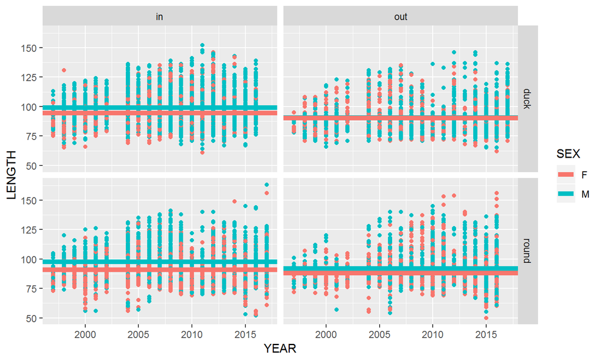

## Exercise: working with `group_by`

Modify the following code so that you are calculating the length of time that each tag value has been observed for each sex and each island (remember to use ungroup at the end!)

```r
legal_size_tags <- tidy_tags %>%
    mutate(LEGAL_SIZE = LENGTH > 82.5,
           SIDE = tolower(SIDE)) %>%
    filter(LEGAL_SIZE == TRUE) %>%
    mutate(YEARS_OBS = max(YEAR)-min(YEAR))%>%
    filter(YEARS_OBS >0)
```

## Exercise: working with `group_by`

Modify the following code so that you are calculating the length of time that each tag value has been observed for each sex and each island (remember to use ungroup at the end!)

```r
legal_size_tags <- tidy_tags %>%
    mutate(LEGAL_SIZE = LENGTH > 82.5,
           SIDE = tolower(SIDE)) %>%
    filter(LEGAL_SIZE == TRUE) %>%
    group_by(TAG,SEX, ISLAND)%>%
    mutate(YEARS_OBS = max(YEAR)-min(YEAR))%>%
    filter(YEARS_OBS >0)%>%
    ungroup()
```

## Now we can (almost) create the first plot we saw:

```r
legal_size_tags <- tidy_tags %>%
    mutate(LEGAL_SIZE = LENGTH > 82.5,
           SIDE = tolower(SIDE)) %>%
    filter(LEGAL_SIZE == TRUE) %>%
    group_by(TAG,SEX, ISLAND)%>%
    mutate(YEARS_OBS = max(YEAR)-min(YEAR))%>%
    filter(YEARS_OBS >0)%>%
    ungroup()

longest_observed_lobsters <- legal_size_tags %>%
    group_by(SEX,ISLAND)%>%
    filter(YEARS_OBS == max(YEARS_OBS))%>%
    ungroup()
```

## Now we can (almost) create the first plot we saw:

```r
size_plot <- legal_size_tags %>%
    ggplot(aes(x = YEAR, y = LENGTH, color = SEX))+
    facet_grid(SEX~ISLAND)+
    geom_line(aes(group = TAG),alpha=0.25)+
    geom_line(data= longest_observed_lobsters,
              aes(group = TAG),
              size=2)

print(size_plot)
```

## Now we can (almost) create the first plot we saw:

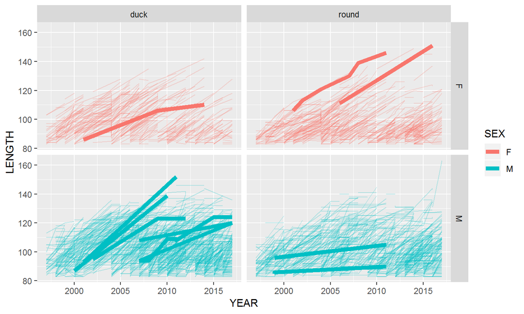

(There's code at the end of the script file we sent you that shows how to make this figure even prettier)

## `summarize()`: Summarizing your data into a single row

The last function we'll look at today is `summarize()`

- reduces the data down to a single row (if ungrouped) or one row per group (if you've used `group_by()`
- You need to use functions that return a single value (like `mean()`, max()`, etc)
- You can make as many summary statistics as you want

## `summarize()`: Summarizing your data into a single row

As an example, let's get the minimum, average, and maximum length for lobsters inside and outside each protected area:

```r
average_lengths <- tidy_tags %>%
    group_by(ISLAND,SIDE ) %>%
    summarize(LENGTH_AVG = mean(LENGTH),
              LENGTH_MIN = min(LENGTH),
              LENGTH_MAX = max(LENGTH))%>%
    #It's always important to use ungroup after doing the grouped action
    ungroup()

average_lengths
```

## `summarize()`: Summarizing your data into a single row

```
## # A tibble: 4 x 5
##   ISLAND SIDE  LENGTH_AVG LENGTH_MIN LENGTH_MAX
##   <chr>  <chr>      <dbl>      <dbl>      <dbl>
## 1 duck   in          98.2         61        152
## 2 duck   out         90.7         62        146
## 3 round  in          95.0         52        163
## 4 round  out         90.3         50        156
```

## Using `summarize()` to learn about your data:

`summarize` can also be used to do some pretty useful data sorting, when combined with different verbs:

```r
lobster_growth_rates = legal_size_tags %>%
    group_by(TAG, SEX, ISLAND)%>%
    filter(max(YEAR)>min(YEAR))%>%
    summarize(LENGTH_START = min(LENGTH),
              GROWTH_RATE = (max(LENGTH)-min(LENGTH))/(max(YEAR)-min(YEAR)))%>%
    ungroup()

lobster_growth_rates
```

## Using `summarize()` to learn about your data:

`summarize` can also be used to do some pretty useful data sorting, when combined with different verbs:

```
## # A tibble: 2,749 x 5
##    TAG     SEX   ISLAND LENGTH_START GROWTH_RATE
##    <chr>   <chr> <chr>         <dbl>       <dbl>
##  1 DF30007 M     duck             86        4.67
##  2 DF30012 M     duck            106        0
##  3 DF30029 M     duck            109        1
##  4 DF30030 M     duck             90        5
##  5 DF30031 F     duck             86        1.85
##  6 DF30036 M     duck             97        7
##  7 DF30041 M     duck             92        5.33
##  8 DF30065 M     duck             98        4.67
##  9 DF30070 M     duck             83        4.33
## 10 DF30071 M     duck            110        4
## # ... with 2,739 more rows
```

## Using `summarize()` to learn about your data:

This can all be combined into a new plot:

```r
growth_plot = lobster_growth_rates %>%
    ggplot(aes(x = LENGTH_START, GROWTH_RATE,color = SEX))+
    facet_grid(SEX~ISLAND)+
    geom_point()

growth_plot
```

## Using `summarize()` to learn about your data:

This can all be combined into a new plot:

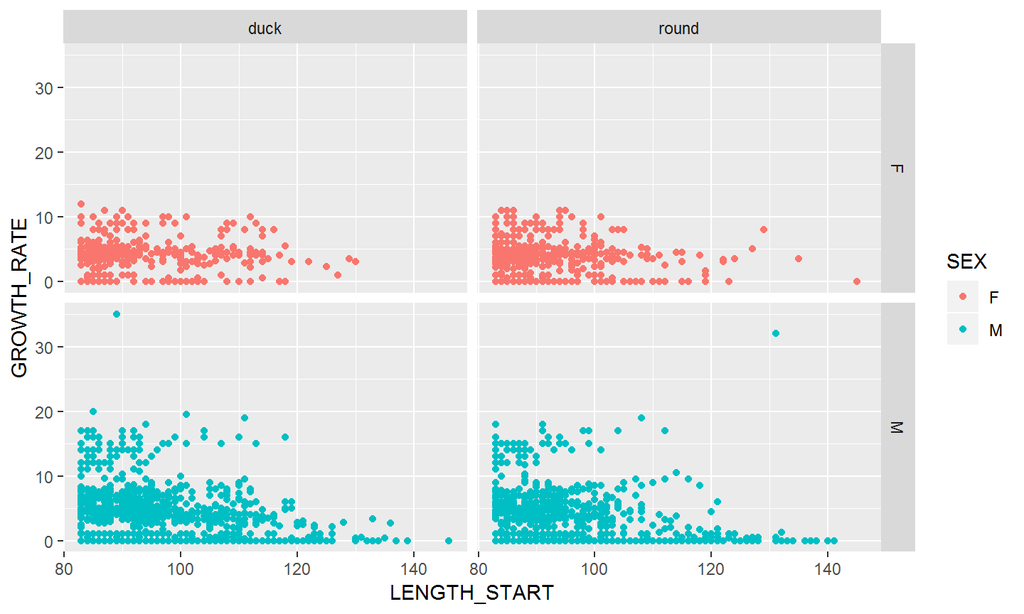

## Useful resources:

The intro to `dplyr`:

https://cran.r-project.org/web/packages/dplyr/vignettes/dplyr.html

The `dplyr` website on tidyverse.org:

https://dplyr.tidyverse.org/